# ΜΙΣΤΑ002: Type of Errors and Power of the test

## Type of Errors and Power of the test

**Types of error in hypothesis testing**

- **Type I error:** we reject the null hypothesis when it is true, and conclude that there is an effect when, in reality, there is none. The maximum chance (probability) of making a Type I error is denoted by α (alpha). This is the significance level of the test; we reject the null hypothesis if our p-value is less than the significance level, i.e. if p < a.
- **Type II error:** we do not reject the null hypothesis when it is false, and conclude that there is no effect when one really exists. The chance of making a Type II error is denoted by β (beta); its compliment, (1 - β), is the **power of the test**. The power, therefore, is the probability of rejecting the null hypothesis when it is false; i.e. it is the chance (usually expressed as a percentage) of detecting, as statistically significant, a real treatment effect of a given size.

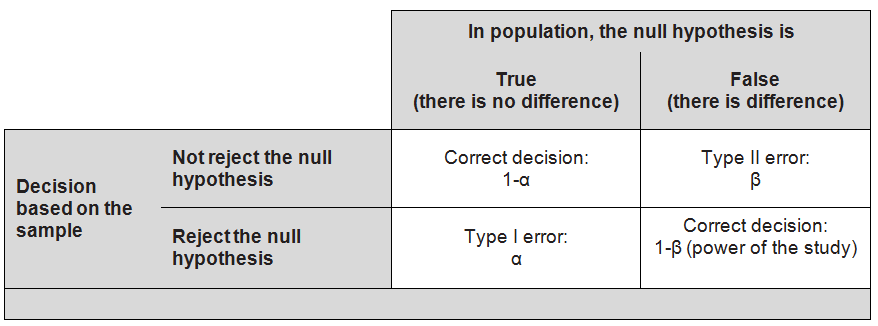

**Increasing the Power of the test**

A number of factors have a direct effect on power for a given test.

- **The sample size:** power increases with increasing sample size. This means that a large sample has a greater ability than a small sample to detect a clinically important effect if it exists. When the sample size is very small, the test may have an inadequate power to detect a particular effect.
- **The variability of the observations:** power increases as the variability of the observations decreases (cf figure 1).
- **The effect of interest:** the power of the test is greater for larger effects. A hypothesis test thus has a greater chance of detecting a large real effect than a small one.
- **The significance level (alpha) of the test:** the power is greater if the significance level is larger (this is equivalent to the probability of the Type I error increasing as the probability of the Type II error decreases). So, we are more likely to detect a real effect if we decide at the planning stage that we will regard our p-value as significant if it is less than 0.05 rather than less than 0.01. We can see this relationship between power and the significance level in figure 2.

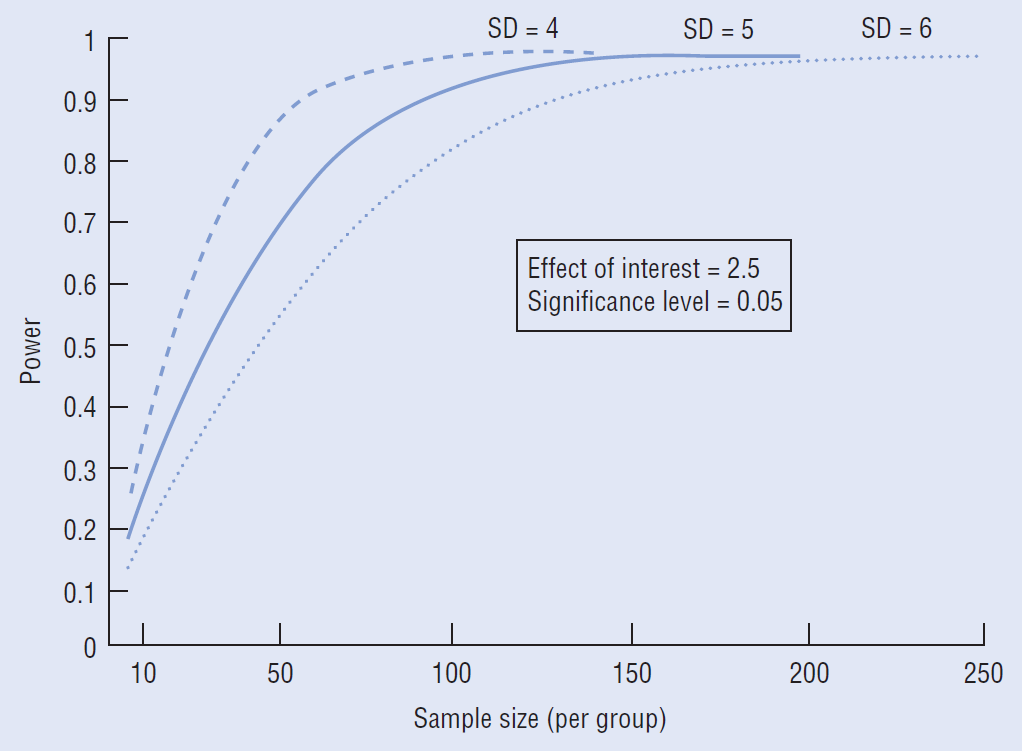

**Figure 1.** Power curves showing the relationship between power and the sample size in each of two groups for the comparison of two means using the two-sample t-test. Each power curve relates to a two-sided test for which the significance level is 0.05, and the effect of interest (e.g. the difference between the treatment means) is 2.5. The assumed equal standard deviation of the measurements in the two groups is different for each power curve. *(Figure reprinted from Aviva P. & Sabin C. 2005)*

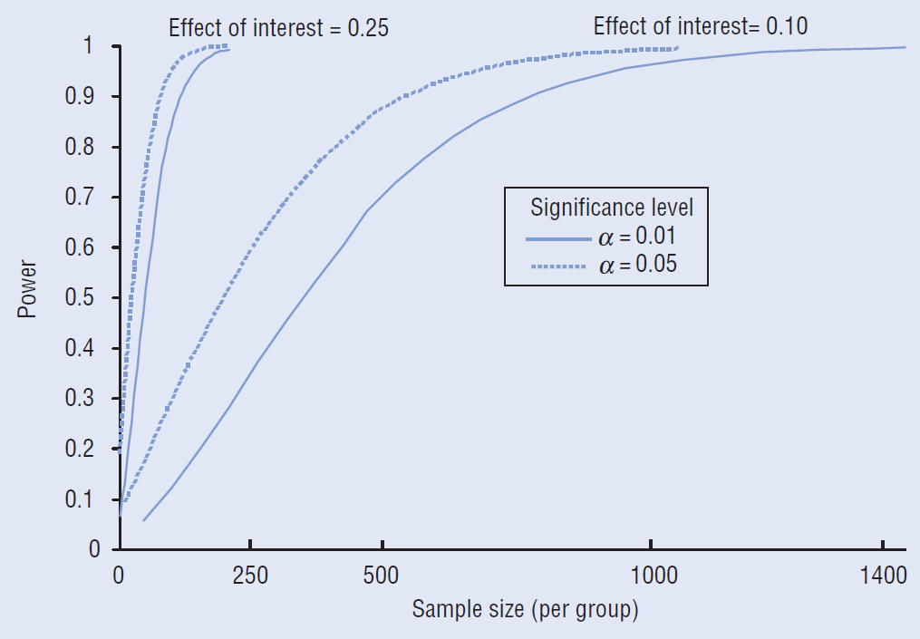

**Figure 2.** Power curves showing the relationship between power and the sample size in each of two groups for the comparison of two proportions using the Chi-square test. Curves are drawn when the effect of interest (e.g. the difference in the proportions with the characteristic of interest in the two treatment groups) is either 0.25 (i.e. 0.65 - 0.40) or 0.10 (i.e. 0.50 - 0.40); the significance level of the two-sided test is either 0.05 or 0.01. *(Figure reprinted from Aviva P. & Sabin C. 2005)*

**Information from the Confidence Intervals**

An inspection of the confidence interval for the effect of interest gives an indication of whether the power of the test was adequate. A wide confidence interval results from a small sample and/or data with substantial variability, and is a suggestion of low power.

*____________________________________*

*Aviva, P., Sabin, C. (2005). *Medical Statistics at a Glance* *(2<sup>nd</sup> Ed.)* UK: Blackwell Publishing.*

Last modified: Wednesday, 13 February 2019, 8:01 PM